# Customer Clustering Using Kmeans

## Import libraries

```python
import numpy as np
import pandas as pd
import matplotlib.pyplot as plt
import seaborn as sns
import plotly.express as px
import plotly.graph_objects as go
from sklearn.preprocessing import LabelEncoder, StandardScaler
from sklearn.decomposition import PCA
from sklearn.cluster import KMeans, AgglomerativeClustering

import warnings
warnings.filterwarnings('ignore')
```

**Dataset Columns Description**

- **ID:** Customer's unique identifier
- **Year_Birth:** Customer's birth year
- **Education:** Customer's education level
- **Marital_Status:** Customer's marital status
- **Income:** Customer's yearly household income
- **Kidhome:** Number of children in customer's household
- **Teenhome:** Number of teenagers in customer's household
- **Dt_Customer:** Date of customer's enrollment with the company
- **Recency:** Number of days since customer's last purchase
- **Complain:** 1 if the customer complained in the last 2 years, 0 otherwise
- **MntWines:** Amount spent on wine in last 2 years
- **MntFruits:** Amount spent on fruits in last 2 years
- **MntMeatProducts:** Amount spent on meat in last 2 years
- **MntFishProducts:** Amount spent on fish in last 2 years
- **MntSweetProducts:** Amount spent on sweets in last 2 years
- **MntGoldProds:** Amount spent on gold in last 2 years
- **NumDealsPurchases:** Number of purchases made with a discount
- **AcceptedCmp1:** 1 if customer accepted the offer in the 1st campaign, 0 otherwise
- **AcceptedCmp2:** 1 if customer accepted the offer in the 2nd campaign, 0 otherwise
- **AcceptedCmp3:** 1 if customer accepted the offer in the 3rd campaign, 0 otherwise
- **AcceptedCmp4:** 1 if customer accepted the offer in the 4th campaign, 0 otherwise
- **AcceptedCmp5:** 1 if customer accepted the offer in the 5th campaign, 0 otherwise
- **Response:** 1 if customer accepted the offer in the last campaign, 0 otherwise
- **NumWebPurchases:** Number of purchases made through the company’s website
- **NumCatalogPurchases:** Number of purchases made using a catalogue
- **NumStorePurchases:** Number of purchases made directly in stores
- **NumWebVisitsMonth:** Number of visits to company’s website in the last month

## Import Data and Exploration

```python
data = pd.read_csv("marketing_campaign.csv", sep="\t")
```

```python
data
```

|  | ID | Year_Birth | Education | Marital_Status | Income | Kidhome | Teenhome | Dt_Customer | Recency | MntWines | ... | NumWebVisitsMonth | AcceptedCmp3 | AcceptedCmp4 | AcceptedCmp5 | AcceptedCmp1 | AcceptedCmp2 | Complain | Z_CostContact | Z_Revenue | Response |
| --- | --- | --- | --- | --- | --- | --- | --- | --- | --- | --- | --- | --- | --- | --- | --- | --- | --- | --- | --- | --- | --- |
| 0 | 5524 | 1957 | Graduation | Single | 58138.0 | 0 | 0 | 04-09-2012 | 58 | 635 | ... | 7 | 0 | 0 | 0 | 0 | 0 | 0 | 3 | 11 | 1 |
| 1 | 2174 | 1954 | Graduation | Single | 46344.0 | 1 | 1 | 08-03-2014 | 38 | 11 | ... | 5 | 0 | 0 | 0 | 0 | 0 | 0 | 3 | 11 | 0 |
| 2 | 4141 | 1965 | Graduation | Together | 71613.0 | 0 | 0 | 21-08-2013 | 26 | 426 | ... | 4 | 0 | 0 | 0 | 0 | 0 | 0 | 3 | 11 | 0 |
| 3 | 6182 | 1984 | Graduation | Together | 26646.0 | 1 | 0 | 10-02-2014 | 26 | 11 | ... | 6 | 0 | 0 | 0 | 0 | 0 | 0 | 3 | 11 | 0 |
| 4 | 5324 | 1981 | PhD | Married | 58293.0 | 1 | 0 | 19-01-2014 | 94 | 173 | ... | 5 | 0 | 0 | 0 | 0 | 0 | 0 | 3 | 11 | 0 |
| ... | ... | ... | ... | ... | ... | ... | ... | ... | ... | ... | ... | ... | ... | ... | ... | ... | ... | ... | ... | ... | ... |
| 2235 | 10870 | 1967 | Graduation | Married | 61223.0 | 0 | 1 | 13-06-2013 | 46 | 709 | ... | 5 | 0 | 0 | 0 | 0 | 0 | 0 | 3 | 11 | 0 |
| 2236 | 4001 | 1946 | PhD | Together | 64014.0 | 2 | 1 | 10-06-2014 | 56 | 406 | ... | 7 | 0 | 0 | 0 | 1 | 0 | 0 | 3 | 11 | 0 |
| 2237 | 7270 | 1981 | Graduation | Divorced | 56981.0 | 0 | 0 | 25-01-2014 | 91 | 908 | ... | 6 | 0 | 1 | 0 | 0 | 0 | 0 | 3 | 11 | 0 |
| 2238 | 8235 | 1956 | Master | Together | 69245.0 | 0 | 1 | 24-01-2014 | 8 | 428 | ... | 3 | 0 | 0 | 0 | 0 | 0 | 0 | 3 | 11 | 0 |
| 2239 | 9405 | 1954 | PhD | Married | 52869.0 | 1 | 1 | 15-10-2012 | 40 | 84 | ... | 7 | 0 | 0 | 0 | 0 | 0 | 0 | 3 | 11 | 1 |

2240 rows × 29 columns

```python
data.info()
```

```
<class 'pandas.core.frame.DataFrame'>
RangeIndex: 2240 entries, 0 to 2239
Data columns (total 29 columns):
 #   Column               Non-Null Count  Dtype
---  ------               --------------  -----
 0   ID                   2240 non-null   int64
 1   Year_Birth           2240 non-null   int64
 2   Education            2240 non-null   object
 3   Marital_Status       2240 non-null   object
 4   Income               2216 non-null   float64
 5   Kidhome              2240 non-null   int64
 6   Teenhome             2240 non-null   int64
 7   Dt_Customer          2240 non-null   object
 8   Recency              2240 non-null   int64
 9   MntWines             2240 non-null   int64
```

[output cut: 21 more lines]

```python
data.describe()
```

|  | ID | Year_Birth | Income | Kidhome | Teenhome | Recency | MntWines | MntFruits | MntMeatProducts | MntFishProducts | ... | NumWebVisitsMonth | AcceptedCmp3 | AcceptedCmp4 | AcceptedCmp5 | AcceptedCmp1 | AcceptedCmp2 | Complain | Z_CostContact | Z_Revenue | Response |
| --- | --- | --- | --- | --- | --- | --- | --- | --- | --- | --- | --- | --- | --- | --- | --- | --- | --- | --- | --- | --- | --- |
| count | 2240.000000 | 2240.000000 | 2216.000000 | 2240.000000 | 2240.000000 | 2240.000000 | 2240.000000 | 2240.000000 | 2240.000000 | 2240.000000 | ... | 2240.000000 | 2240.000000 | 2240.000000 | 2240.000000 | 2240.000000 | 2240.000000 | 2240.000000 | 2240.0 | 2240.0 | 2240.000000 |
| mean | 5592.159821 | 1968.805804 | 52247.251354 | 0.444196 | 0.506250 | 49.109375 | 303.935714 | 26.302232 | 166.950000 | 37.525446 | ... | 5.316518 | 0.072768 | 0.074554 | 0.072768 | 0.064286 | 0.013393 | 0.009375 | 3.0 | 11.0 | 0.149107 |
| std | 3246.662198 | 11.984069 | 25173.076661 | 0.538398 | 0.544538 | 28.962453 | 336.597393 | 39.773434 | 225.715373 | 54.628979 | ... | 2.426645 | 0.259813 | 0.262728 | 0.259813 | 0.245316 | 0.114976 | 0.096391 | 0.0 | 0.0 | 0.356274 |
| min | 0.000000 | 1893.000000 | 1730.000000 | 0.000000 | 0.000000 | 0.000000 | 0.000000 | 0.000000 | 0.000000 | 0.000000 | ... | 0.000000 | 0.000000 | 0.000000 | 0.000000 | 0.000000 | 0.000000 | 0.000000 | 3.0 | 11.0 | 0.000000 |
| 25% | 2828.250000 | 1959.000000 | 35303.000000 | 0.000000 | 0.000000 | 24.000000 | 23.750000 | 1.000000 | 16.000000 | 3.000000 | ... | 3.000000 | 0.000000 | 0.000000 | 0.000000 | 0.000000 | 0.000000 | 0.000000 | 3.0 | 11.0 | 0.000000 |
| 50% | 5458.500000 | 1970.000000 | 51381.500000 | 0.000000 | 0.000000 | 49.000000 | 173.500000 | 8.000000 | 67.000000 | 12.000000 | ... | 6.000000 | 0.000000 | 0.000000 | 0.000000 | 0.000000 | 0.000000 | 0.000000 | 3.0 | 11.0 | 0.000000 |
| 75% | 8427.750000 | 1977.000000 | 68522.000000 | 1.000000 | 1.000000 | 74.000000 | 504.250000 | 33.000000 | 232.000000 | 50.000000 | ... | 7.000000 | 0.000000 | 0.000000 | 0.000000 | 0.000000 | 0.000000 | 0.000000 | 3.0 | 11.0 | 0.000000 |
| max | 11191.000000 | 1996.000000 | 666666.000000 | 2.000000 | 2.000000 | 99.000000 | 1493.000000 | 199.000000 | 1725.000000 | 259.000000 | ... | 20.000000 | 1.000000 | 1.000000 | 1.000000 | 1.000000 | 1.000000 | 1.000000 | 3.0 | 11.0 | 1.000000 |

8 rows × 26 columns

```python
data.describe(include=object)
```

|  | Education | Marital_Status | Dt_Customer |
| --- | --- | --- | --- |
| count | 2240 | 2240 | 2240 |
| unique | 5 | 8 | 663 |
| top | Graduation | Married | 31-08-2012 |
| freq | 1127 | 864 | 12 |

```python
data.isnull().sum()
```

```
ID                      0
Year_Birth              0
Education               0
Marital_Status          0
Income                 24
Kidhome                 0
Teenhome                0
Dt_Customer             0
Recency                 0
MntWines                0
MntFruits               0
MntMeatProducts         0
MntFishProducts         0
MntSweetProducts        0
MntGoldProds            0
NumDealsPurchases       0
NumWebPurchases         0
NumCatalogPurchases     0
NumStorePurchases       0
NumWebVisitsMonth       0
AcceptedCmp3            0
AcceptedCmp4            0
AcceptedCmp5            0
AcceptedCmp1            0
AcceptedCmp2            0
Complain                0
Z_CostContact           0
Z_Revenue               0
Response                0
dtype: int64
```

## Data Preprocessing

```python
data.dropna(axis=0, inplace=True)
```

```python
data["Dt_Customer"] = pd.to_datetime(data["Dt_Customer"])
dates = data["Dt_Customer"].apply(lambda x: x.date()).tolist()
```

```python
data
```

|  | ID | Year_Birth | Education | Marital_Status | Income | Kidhome | Teenhome | Dt_Customer | Recency | MntWines | ... | NumWebVisitsMonth | AcceptedCmp3 | AcceptedCmp4 | AcceptedCmp5 | AcceptedCmp1 | AcceptedCmp2 | Complain | Z_CostContact | Z_Revenue | Response |
| --- | --- | --- | --- | --- | --- | --- | --- | --- | --- | --- | --- | --- | --- | --- | --- | --- | --- | --- | --- | --- | --- |
| 0 | 5524 | 1957 | Graduation | Single | 58138.0 | 0 | 0 | 2012-04-09 | 58 | 635 | ... | 7 | 0 | 0 | 0 | 0 | 0 | 0 | 3 | 11 | 1 |
| 1 | 2174 | 1954 | Graduation | Single | 46344.0 | 1 | 1 | 2014-08-03 | 38 | 11 | ... | 5 | 0 | 0 | 0 | 0 | 0 | 0 | 3 | 11 | 0 |
| 2 | 4141 | 1965 | Graduation | Together | 71613.0 | 0 | 0 | 2013-08-21 | 26 | 426 | ... | 4 | 0 | 0 | 0 | 0 | 0 | 0 | 3 | 11 | 0 |
| 3 | 6182 | 1984 | Graduation | Together | 26646.0 | 1 | 0 | 2014-10-02 | 26 | 11 | ... | 6 | 0 | 0 | 0 | 0 | 0 | 0 | 3 | 11 | 0 |
| 4 | 5324 | 1981 | PhD | Married | 58293.0 | 1 | 0 | 2014-01-19 | 94 | 173 | ... | 5 | 0 | 0 | 0 | 0 | 0 | 0 | 3 | 11 | 0 |
| ... | ... | ... | ... | ... | ... | ... | ... | ... | ... | ... | ... | ... | ... | ... | ... | ... | ... | ... | ... | ... | ... |
| 2235 | 10870 | 1967 | Graduation | Married | 61223.0 | 0 | 1 | 2013-06-13 | 46 | 709 | ... | 5 | 0 | 0 | 0 | 0 | 0 | 0 | 3 | 11 | 0 |
| 2236 | 4001 | 1946 | PhD | Together | 64014.0 | 2 | 1 | 2014-10-06 | 56 | 406 | ... | 7 | 0 | 0 | 0 | 1 | 0 | 0 | 3 | 11 | 0 |
| 2237 | 7270 | 1981 | Graduation | Divorced | 56981.0 | 0 | 0 | 2014-01-25 | 91 | 908 | ... | 6 | 0 | 1 | 0 | 0 | 0 | 0 | 3 | 11 | 0 |
| 2238 | 8235 | 1956 | Master | Together | 69245.0 | 0 | 1 | 2014-01-24 | 8 | 428 | ... | 3 | 0 | 0 | 0 | 0 | 0 | 0 | 3 | 11 | 0 |
| 2239 | 9405 | 1954 | PhD | Married | 52869.0 | 1 | 1 | 2012-10-15 | 40 | 84 | ... | 7 | 0 | 0 | 0 | 0 | 0 | 0 | 3 | 11 | 1 |

2216 rows × 29 columns

```python
# Calculate Customer Loyalty
newest = max(dates)
data["Customer Loyalty"] = (newest - pd.to_datetime(data["Dt_Customer"]).dt.date).dt.days

# Calculate Age
data["Age"] = 2015 - data["Year_Birth"]

# Calculate Total Spent
spending_columns = ["MntWines", "MntFruits", "MntMeatProducts", "MntFishProducts", "MntSweetProducts", "MntGoldProds"]
data["Spent"] = data[spending_columns].sum(axis=1)

# Calculate Parental Status
data["Parental Status"] = np.where(data["Kidhome"] > 0, 1, 0)

# Simplify Marital Status and Education
marital_dict = {"Married": "Couple", "Together": "Couple", "Absurd": "Alone", "Widow": "Alone", "YOLO": "Alone", "Divorced": "Alone", "Single": "Alone"}
edu_dict = {"Basic": "Undergraduate", "2n Cycle": "Undergraduate", "Graduation": "Graduate", "Master": "Postgraduate", "PhD": "Postgraduate"}
data["Marital Status"] = data["Marital_Status"].map(marital_dict)
data["Education"] = data["Education"].map(edu_dict)

# Calculate Total Promo
promo_columns = ["AcceptedCmp1", "AcceptedCmp2", "AcceptedCmp3", "AcceptedCmp4", "AcceptedCmp5"]
data["Total Promo"] = data[promo_columns].sum(axis=1)

# Rename columns
new_column_names = {"MntWines": "Wines", "MntFruits": "Fruits", "MntMeatProducts": "Meat", "MntFishProducts": "Fish", "MntSweetProducts": "Sweets", "MntGoldProds": "Gold", "NumWebPurchases": "Web", "NumCatalogPurchases": "Catalog", "NumStorePurchases": "Store", "NumDealsPurchases": "Discount Purchases"}
data = data.rename(columns=new_column_names)

# Reorder columns and filter data
selected_columns = ["ID", "Age", "Education", "Marital Status", "Parental Status", "Kidhome", "Teenhome", "Income", "Spent", "Customer Loyalty", "Recency", "Wines", "Fruits", "Meat", "Fish", "Sweets", "Gold", "Web", "Catalog", "Store", "Discount Purchases", "Total Promo", "NumWebVisitsMonth"]
data = data[selected_columns]
data = data.loc[(data["Age"] < 90) & (data["Income"] < 600000)]
```

```python
data.dropna(axis=0, inplace=True)
```

```python
data.describe()
```

|  | ID | Age | Parental Status | Kidhome | Teenhome | Income | Spent | Customer Loyalty | Recency | Wines | ... | Meat | Fish | Sweets | Gold | Web | Catalog | Store | Discount Purchases | Total Promo | NumWebVisitsMonth |
| --- | --- | --- | --- | --- | --- | --- | --- | --- | --- | --- | --- | --- | --- | --- | --- | --- | --- | --- | --- | --- | --- |
| count | 2209.000000 | 2209.000000 | 2209.000000 | 2209.000000 | 2209.000000 | 2209.000000 | 2209.000000 | 2209.000000 | 2209.000000 | 2209.000000 | ... | 2209.000000 | 2209.000000 | 2209.000000 | 2209.000000 | 2209.000000 | 2209.000000 | 2209.000000 | 2209.000000 | 2209.000000 | 2209.000000 |
| mean | 5589.040742 | 46.091897 | 0.420100 | 0.440923 | 0.505659 | 51969.905840 | 607.744228 | 512.554097 | 49.044817 | 305.451335 | ... | 167.220914 | 37.689452 | 27.073789 | 43.948846 | 4.086917 | 2.674966 | 5.808963 | 2.322770 | 0.298325 | 5.320054 |
| std | 3245.471735 | 11.699869 | 0.493686 | 0.536925 | 0.544313 | 21534.922418 | 602.704144 | 232.353589 | 28.950534 | 337.399831 | ... | 224.345996 | 54.797242 | 41.111818 | 51.737043 | 2.739217 | 2.928544 | 3.251907 | 1.924629 | 0.679808 | 2.426522 |
| min | 0.000000 | 19.000000 | 0.000000 | 0.000000 | 0.000000 | 1730.000000 | 5.000000 | 0.000000 | 0.000000 | 0.000000 | ... | 0.000000 | 0.000000 | 0.000000 | 0.000000 | 0.000000 | 0.000000 | 0.000000 | 0.000000 | 0.000000 | 0.000000 |
| 25% | 2826.000000 | 38.000000 | 0.000000 | 0.000000 | 0.000000 | 35246.000000 | 69.000000 | 340.000000 | 24.000000 | 24.000000 | ... | 16.000000 | 3.000000 | 1.000000 | 9.000000 | 2.000000 | 0.000000 | 3.000000 | 1.000000 | 0.000000 | 3.000000 |
| 50% | 5455.000000 | 45.000000 | 0.000000 | 0.000000 | 0.000000 | 51373.000000 | 397.000000 | 513.000000 | 49.000000 | 176.000000 | ... | 68.000000 | 12.000000 | 8.000000 | 25.000000 | 4.000000 | 2.000000 | 5.000000 | 2.000000 | 0.000000 | 6.000000 |
| 75% | 8420.000000 | 56.000000 | 1.000000 | 1.000000 | 1.000000 | 68487.000000 | 1048.000000 | 686.000000 | 74.000000 | 505.000000 | ... | 233.000000 | 50.000000 | 33.000000 | 56.000000 | 6.000000 | 4.000000 | 8.000000 | 3.000000 | 0.000000 | 7.000000 |
| max | 11191.000000 | 75.000000 | 1.000000 | 2.000000 | 2.000000 | 162397.000000 | 2525.000000 | 1063.000000 | 99.000000 | 1493.000000 | ... | 1725.000000 | 259.000000 | 262.000000 | 321.000000 | 27.000000 | 28.000000 | 13.000000 | 15.000000 | 4.000000 | 20.000000 |

8 rows × 21 columns

```python
data.describe(include=object)
```

|  | Education | Marital Status |
| --- | --- | --- |
| count | 2209 | 2209 |
| unique | 3 | 2 |
| top | Graduate | Couple |
| freq | 1114 | 1428 |

## Exploratory Data Analysis

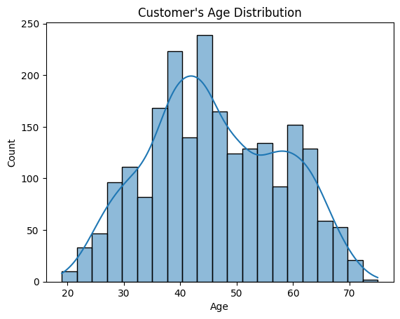

```python
sns.histplot(data["Age"], kde=True)
plt.title("Customer's Age Distribution")
plt.ylabel("Count")
plt.xlabel("Age")

plt.show()
```

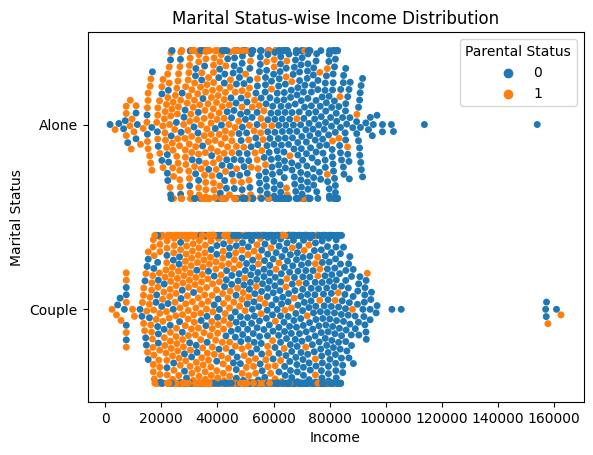

```python
sns.swarmplot(x=data["Income"],y=data["Marital Status"],hue=data["Parental Status"])
plt.title("Marital Status-wise Income Distribution")
plt.xlabel("Income")
plt.ylabel("Marital Status")

plt.show()
```

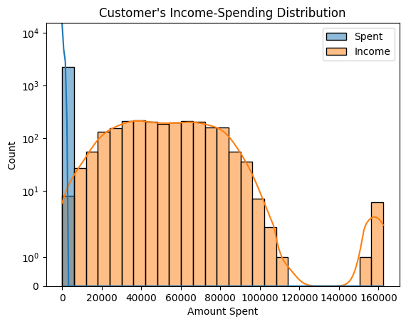

```python
sns.histplot(data[["Spent","Income"]], kde=True, fill=True)
plt.yscale("symlog")
plt.title("Customer's Income-Spending Distribution")
plt.ylabel("Count")
plt.xlabel("Amount Spent")

plt.show()
```

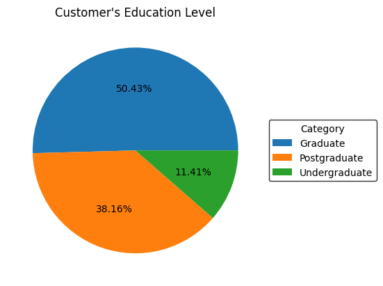

```python
plt.pie([data["Education"].value_counts()[0], data["Education"].value_counts()[1], data["Education"].value_counts()[2]], autopct="%.2f%%")

labels = "Graduate","Postgraduate","Undergraduate"
plt.legend(labels, title="Category",loc="center left",bbox_to_anchor=(1, 0, 0.5, 1), edgecolor = "black")
plt.title("Customer's Education Level")
plt.show()
```

[output not shown]

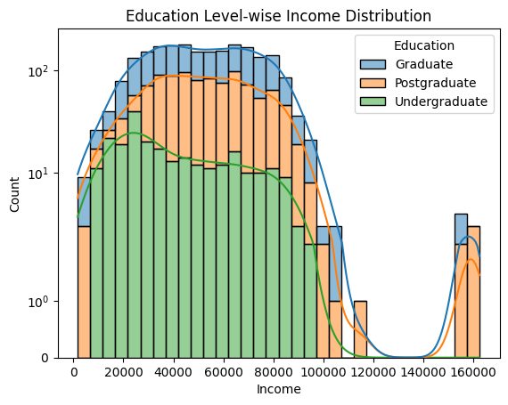

```python
sns.histplot(data=data, x="Income", hue="Education", multiple="stack", kde=True)
plt.yscale("symlog")
plt.title("Education Level-wise Income Distribution")
plt.ylabel("Count")
plt.xlabel("Income")
plt.plot()
```

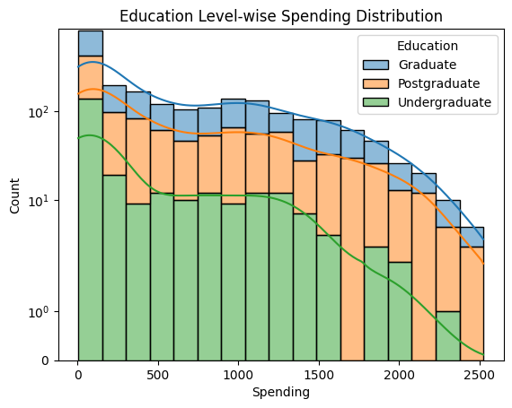

```python
sns.histplot(data=data, x="Spent", hue="Education", multiple="stack" ,kde=True)
plt.yscale("symlog")
plt.title("Education Level-wise Spending Distribution")
plt.ylabel("Count")
plt.xlabel("Spending")
plt.show()
```

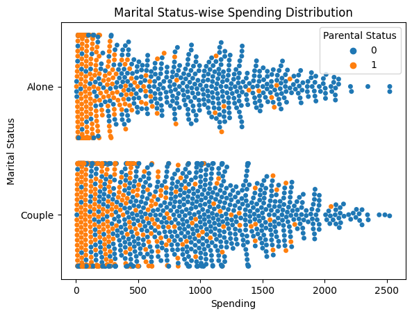

```python
sns.swarmplot(x=data["Spent"],y=data["Marital Status"],hue=data["Parental Status"])
plt.title("Marital Status-wise Spending Distribution")
plt.xlabel("Spending")
plt.ylabel("Marital Status")
plt.show()
```

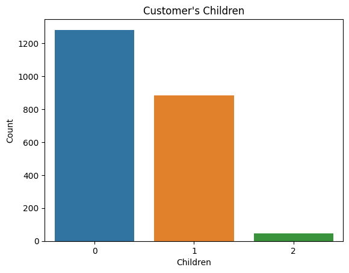

```python
sns.countplot(x=data["Kidhome"])
plt.title("Customer's Children")
plt.xlabel("Children")
plt.ylabel("Count")
plt.show()
```

## Correlation Map

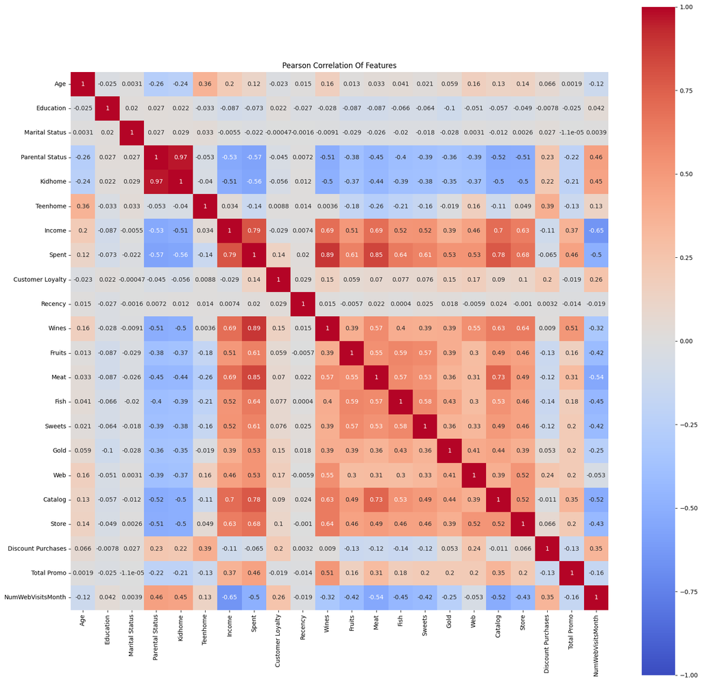

```python
catcol = ["Education","Marital Status"]
le = LabelEncoder()
for col in catcol:
        data[col] = le.fit_transform(data[col])

plt.figure(figsize =(20, 20))

sns.heatmap(data.drop(columns="ID").corr(), square=True, cmap = 'coolwarm',
            edgecolor= 'black', annot=True, vmin=-1, vmax=1)
plt.title("Pearson Correlation Of Features")
plt.xticks(rotation=90)
plt.show()
```

## Data Preprocessing

```python
df = data.copy()
scaler = StandardScaler()
df = scaler.fit_transform(df)
scaled_data = pd.DataFrame(df, columns= data.columns)
```

```python
scaled_df = scaled_data.copy()
pca = PCA(n_components = 3,random_state = 0)
scaled_df = pca.fit_transform(scaled_df)
pca_data = pd.DataFrame(scaled_df, columns=["col1","col2", "col3"])

x = pca_data["col1"]
y = pca_data["col2"]
z = pca_data["col3"]
```

```python
fig = go.Figure(data=[go.Scatter3d(x=x, y=y, z=z, mode='markers', marker=dict(size=2, opacity=0.5))])
fig.update_layout(title="3D Scatter Plot of PCA Components ",
                  scene=dict(xaxis=dict(title="col1"),
                             yaxis=dict(title="col2"),
                             zaxis=dict(title="col3")))
fig.show()
```

[output not shown]

## Customer Segmentation

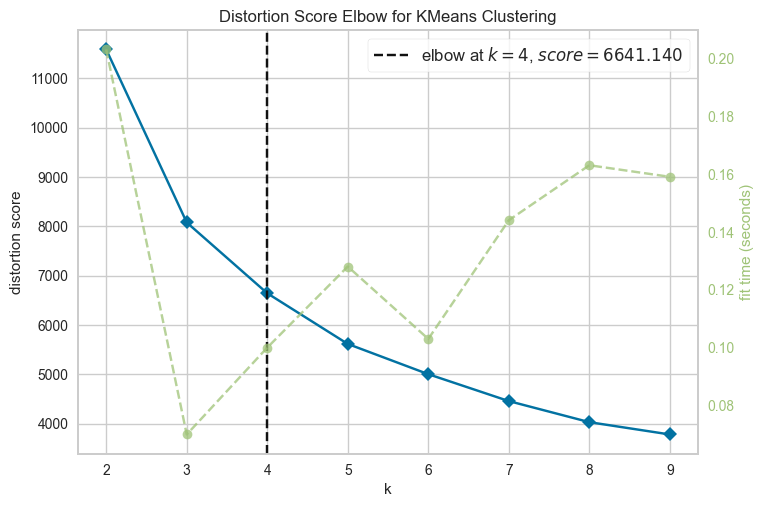

```python
from sklearn.cluster import KMeans
from yellowbrick.cluster import KElbowVisualizer

elbow = KElbowVisualizer(KMeans(), k=(2,10))
elbow.fit(pca_data)
elbow.show()
```

```python
k = elbow.elbow_value_

kmeans = KMeans(n_clusters=k, random_state=0)
kmeans.fit_predict(pca_data)
labels = kmeans.labels_
labels
```

```
array([1, 2, 1, ..., 1, 3, 0])
```

```python
pca_data['Clusters'] = labels
data['Clusters'] = labels
```

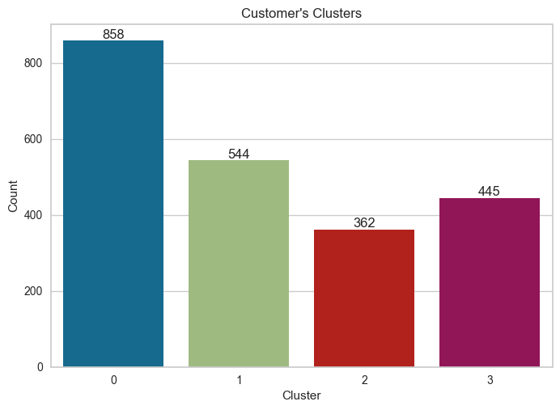

```python
sns.countplot(x=data["Clusters"])
plt.title("Customer's Clusters")
plt.ylabel("Count")
plt.xlabel("Cluster")

for index, value in enumerate(data["Clusters"].value_counts().sort_index()):
    plt.annotate(str(value), xy=(index, value), xytext=(0, 5), ha='center', va='center', textcoords='offset points')

plt.show()
```

```python
fig = go.Figure(data = [go.Scatter3d(x=x, y=y, z=z,mode='markers',
                marker = dict(size=3, color=pca_data["Clusters"], colorscale=["#0080ff", "#ffa500", "#ff0000", "#00cc00"], opacity=1))])
fig.update_layout(title=dict(text= "3D Projection Of The Dataset After Clustering", x=0.5, y=0.9, xanchor='center', yanchor='top'))
fig.show()
```

[output not shown]

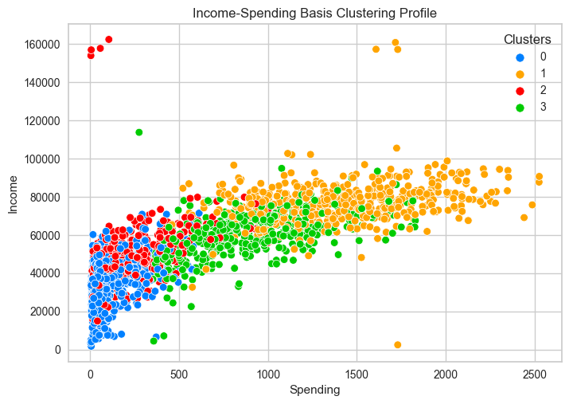

```python
sns.scatterplot(x=data["Spent"], y=data["Income"], hue=data["Clusters"], palette=["#0080ff", "#ffa500", "#ff0000", "#00cc00"])
plt.title("Income-Spending Basis Clustering Profile")
plt.ylabel("Income")
plt.xlabel("Spending")

plt.show()
```

[figure not shown]

```python
sns.boxenplot(x=data["Clusters"], y=data["Spent"])

plt.title("Spending Based Clustering Profile")
plt.ylabel("Income")
plt.xlabel("Spending")
plt.show()
```

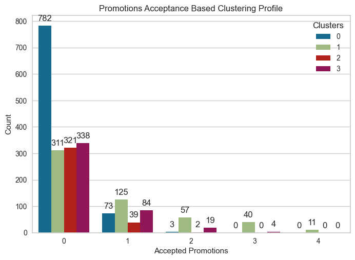

```python
ax = sns.countplot(x=data["Total Promo"],hue=data["Clusters"])
plt.title("Promotions Acceptance Based Clustering Profile")
plt.ylabel("Count")
plt.xlabel("Accepted Promotions")

# Ajouter les étiquettes de données
for p in ax.patches:
    ax.annotate(format(p.get_height(), '.0f'),
                   (p.get_x() + p.get_width() / 2., p.get_height()),
                   ha = 'center', va = 'center',
                   xytext = (0, 10),
                   textcoords = 'offset points')

plt.show()
```

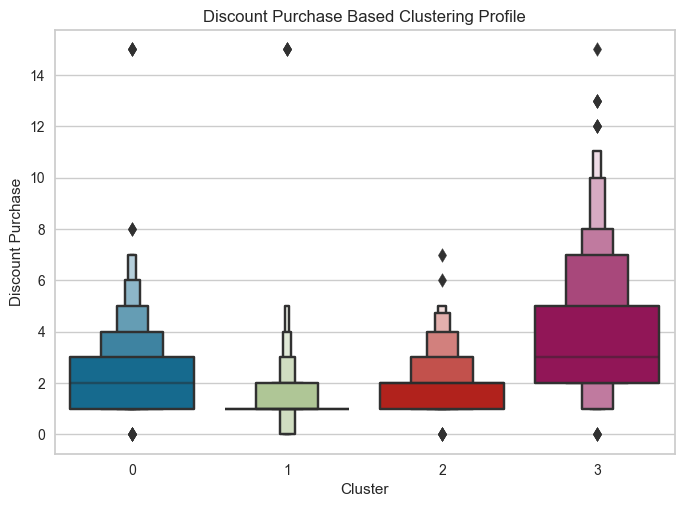

```python
sns.boxenplot(x=data["Clusters"], y=data["Discount Purchases"])

plt.title("Discount Purchase Based Clustering Profile")
plt.ylabel("Discount Purchase")
plt.xlabel("Cluster")
plt.show()
```

```python
def cluster(feature):

    sns.kdeplot(x=data[feature], y=data["Spent"], hue =data["Clusters"], kind="kde",height=10)
    plt.title(f"Clustering Profile On {feature}")
    plt.ylabel("Spending")
    plt.xlabel(f"{feature}")

    plt.show()
```

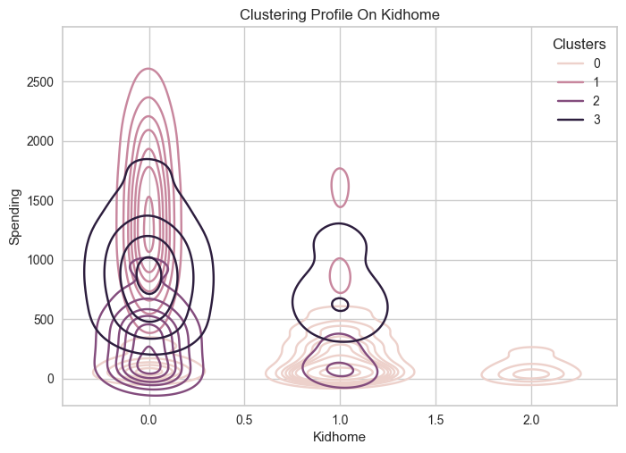

```python
cluster("Kidhome")
```

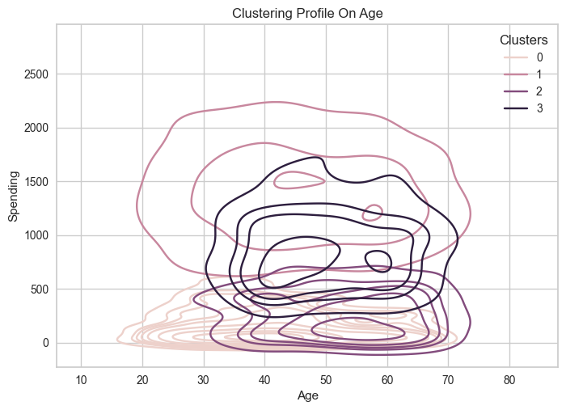

```python
cluster("Age")
```

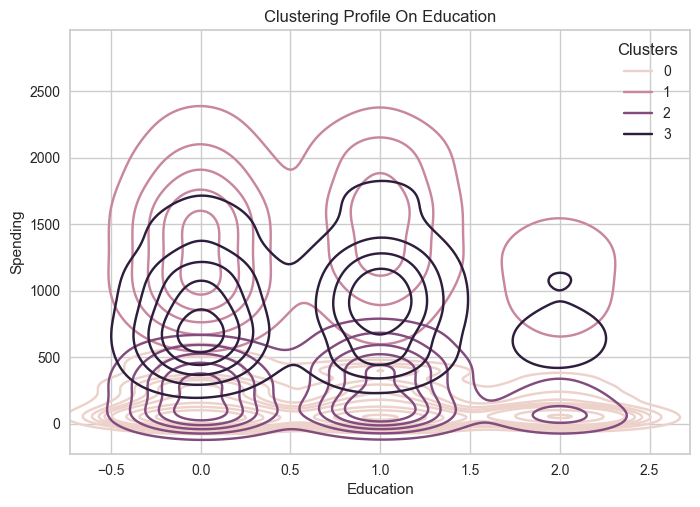

```python
cluster("Education")
```

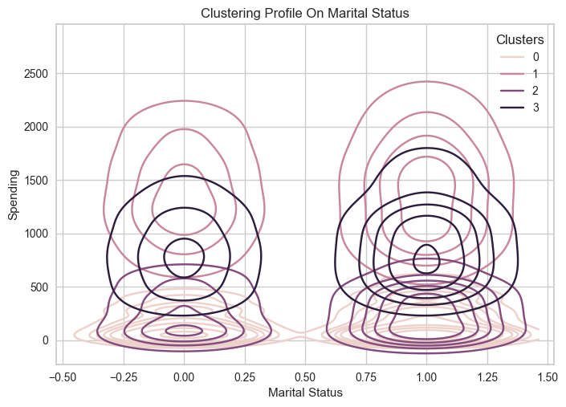

```python
cluster("Marital Status")
```

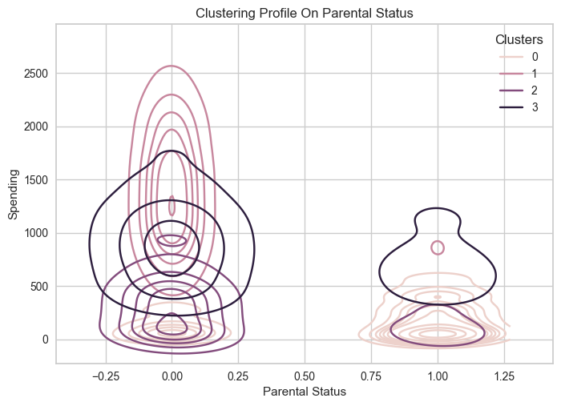

```python
cluster("Parental Status")
```

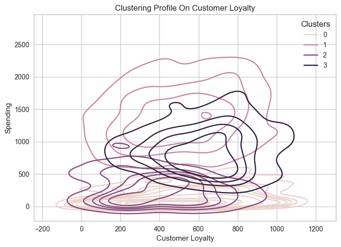

```python
cluster("Customer Loyalty")
```

## Clustering Profile Summary

#### Cluster 1

- Income range is in between 65000 to 85000 and spending range is in between 550 to 2000
- Age range in between 30 to 60
- Almost all have completed graduation
- Most of them are married
- They are not parents
- Have no child
- Customer for at least 250 days
- Promotion acceptance ratio is 0.5
- Completing purchases using discounts are rare